# Movement Analysis Project

Chahine ABDEL-HAMID

Master 2 REHAB — Movement Analysis Project

## 1. Context

The stretch-shortening cycle (SSC) is a fundamental component of force production in dynamic movements. It consists of a rapid eccentric phase immediately followed by a concentric contraction, allowing the storage and reutilization of elastic energy and improving force production. In vertical jumping, the SSC contributes to performance by increasing jump height when a countermovement is performed before take-off. This explains why the Countermovement Jump (CMJ) generally produces greater jump height than the Squat Jump (SJ), which is performed from a static position and relies mainly on concentric force production.

However, in pathological conditions affecting the lower limb, such as patellar tendinopathy, movement strategies may be altered. Previous work by Ben Zaki and colleagues (2025) has shown that athletes with patellar tendinopathy can modify their jumping and landing mechanics, particularly at the knee, suggesting adaptations in the way force is produced and absorbed during explosive tasks.

Therefore, comparing SJ and CMJ performance may provide insight into whether the functional contribution of the stretch-shortening cycle is preserved in individuals with patellar tendinopathy.

## 2. Aim

The aim of this project was to compare jump height between Squat Jump (SJ) and Countermovement Jump (CMJ) in individuals with patellar tendinopathy, using the difference in performance between both jump modalities as an indirect indicator of stretch-shortening cycle contribution.

## 3. Hypothesis

It was hypothesized that jump height would be greater in the CMJ condition than in the SJ condition. This difference was interpreted as an indirect functional indicator of SSC contribution.

## 4. Methods

### Participants

The sample included 12 high-level athletes diagnosed with patellar tendinopathy. Each participant performed both jump conditions, which justified a within-subject paired analysis.

### Outcome measure

The primary outcome extracted from each file was **Jump Height (Flight Time) [cm]**. Only the *Mean* value was retained for each condition.

Jump height derived from flight time estimates the vertical displacement of the center of mass during the airborne phase, assuming ballistic motion and equivalent center of mass position at take-off and landing.

Formula:

`h = (t² × g) / 8`

### Data organization

| Element | Description |
| --- | --- |
| *SJ.xlsx* | File containing Squat Jump results for each participant. |
| *CMJ.xlsx* | File containing Countermovement Jump results for each participant. |
| **Jump Height (Flight Time) [cm]** | Main variable extracted for the analysis. |
| *Global_Jump_Height.xlsx* | Cleaned paired dataset generated with Python and used in R. |
| *Plot/* | Folder containing the exported figures used in this report. |

## 5. Analysis workflow

The project followed a two-step workflow. Python was used first to automate data extraction, clean the dataset, and generate descriptive visualizations. R was then used to perform the statistical analysis.

| Step | Tool | Purpose |
| --- | --- | --- |
| Data extraction | Python | Extract mean jump height from SJ and CMJ files. |
| Data cleaning | Python | Create a paired dataset with one row per participant. |
| Visualization | Python | Generate a boxplot and a paired plot. |
| Statistical analysis | R | Test whether CMJ height was significantly greater than SJ height. |

## 6. Python analysis

Python was used to automate data extraction, clean the dataset, and generate visualizations. The full code is provided below to ensure transparency and reproducibility.

### 6.1 Data extraction and cleaning

This section extracts the variable **Jump Height (Flight Time) [cm]** from each participant folder inside the *data/* directory. Only the files *SJ.xlsx* and *CMJ.xlsx* were used.

Because the Excel files exported from the force-platform software contained additional formatting and metadata, the raw files could not be analyzed directly. A custom Python function was therefore implemented to automatically identify the row containing the true variable headers and reconstruct a clean dataframe before extraction.

The script then searched specifically for the variable **Jump Height (Flight Time) [cm]** and extracted the corresponding *Mean* value for each jump condition. Only the mean value was retained in order to obtain one representative value per participant for both SJ and CMJ conditions.

All extracted values were converted into numeric format and merged into a paired dataframe containing one row per participant and two variables:

- **SJ_Mean**
- **CMJ_Mean**

This cleaned dataset was finally exported as *Global_Jump_Height.xlsx* and used for the subsequent statistical analysis performed in R.

**Show Python code**

```python
import os
import pandas as pd

#----- Creation of the dataframe -----

# Folder containing one subfolder per participant
data_folder = "data"

# Function used to rebuild the dataframe with the correct headers
def read_clean_df(file_path):
    df = pd.read_excel(file_path, header=None)

    # Find the row containing the true headers ("Name")
    header_row = df[df.apply(lambda row: row.astype(str).str.contains("Name").any(), axis=1)].index[0]

    # Rebuild the dataframe using the detected header row
    df.columns = df.iloc[header_row]
    df = df.iloc[header_row + 1:].reset_index(drop=True)

    return df

# List used to store the final cleaned values
data = []

# Browse all participant folders
for patient in os.listdir(data_folder):
    patient_path = os.path.join(data_folder, patient)

    # Ignore files that are not folders
    if not os.path.isdir(patient_path):
        continue

    # Store one value for each jump condition
    values = {"SJ_Mean": None, "CMJ_Mean": None}

    # Read only SJ and CMJ files
    for file in ["SJ.xlsx", "CMJ.xlsx"]:
        file_path = os.path.join(patient_path, file)

        # Skip if the expected file does not exist
        if not os.path.exists(file_path):
            continue

        try:
            df = read_clean_df(file_path)

            # Select the row corresponding to Jump Height
            row = df[df["Name"] == "Jump Height (Flight Time) [cm]"]

            # Extract the Mean value
            mean_value = float(row["Mean"].iloc[0])

            # Store the value according to the jump condition
            if file == "SJ.xlsx":
                values["SJ_Mean"] = mean_value
            elif file == "CMJ.xlsx":
                values["CMJ_Mean"] = mean_value

        except Exception as e:
            print(f"Error with {file_path}: {e}")

    # Add participant data only if both conditions are available
    if values["SJ_Mean"] is not None and values["CMJ_Mean"] is not None:
        values["Participant"] = patient
        data.append(values)

# Create the final dataframe
df_final = pd.DataFrame(data)

# Reorder columns
df_final = df_final[["Participant", "SJ_Mean", "CMJ_Mean"]]

# Export the cleaned dataset
df_final.to_excel("data/Global_Jump_Height.xlsx", index=False)

# Display the final dataframe
df_final
```

### 6.2 Data visualization

Two figures were generated. The boxplot provides a distribution-level comparison between SJ and CMJ, while the paired plot shows the individual change from SJ to CMJ for each participant.

**Show Python code**

```python
import pandas as pd
import matplotlib.pyplot as plt

# Read the cleaned file created in the previous step
df = pd.read_excel("data/Global_Jump_Height.xlsx")

# ----- BOXPLOT -----
plt.figure(figsize=(8, 6))
plt.boxplot([df["SJ_Mean"], df["CMJ_Mean"]], tick_labels=["SJ", "CMJ"])
plt.ylabel("Jump Height (cm)")
plt.title("SJ Height [cm] vs CMJ Height [cm]")
plt.grid(color="grey", linestyle="--", alpha=0.5)
plt.show()

# ----- PAIRED PLOT -----
plt.figure(figsize=(8, 6))

# Plot one line per participant
for i in range(len(df)):
    plt.plot(
        ["SJ", "CMJ"],
        [df.iloc[i]["SJ_Mean"], df.iloc[i]["CMJ_Mean"]],
        marker="o"
    )

# Add the group mean
sj_mean = df["SJ_Mean"].mean()
cmj_mean = df["CMJ_Mean"].mean()
plt.plot(["SJ", "CMJ"], [sj_mean, cmj_mean], color="red", linewidth=1, marker="o", linestyle="--")

plt.ylabel("Jump Height (cm)")
plt.title("Individual Changes from SJ to CMJ")
plt.grid(color="grey", linestyle="--", alpha=0.5)
plt.show()
```

### 6.3 Python outputs

#### Boxplot: SJ vs CMJ

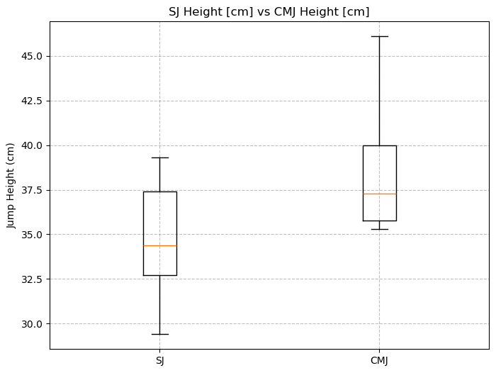

The boxplot suggests that jump height values were generally higher in the CMJ condition than in the SJ condition.

#### Paired plot: individual changes from SJ to CMJ

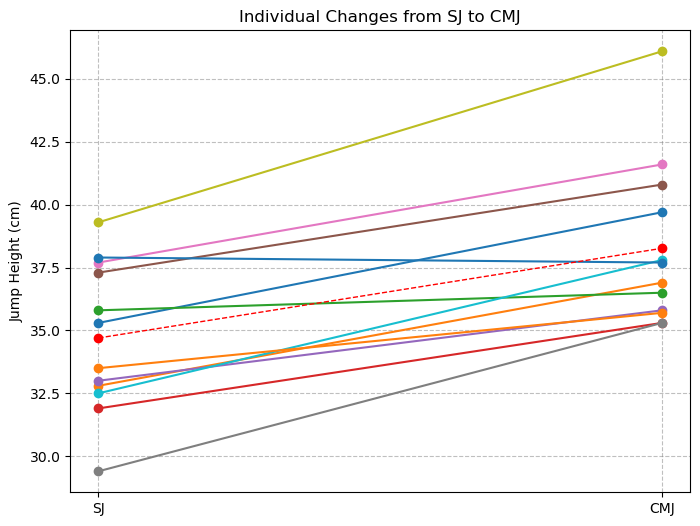

The paired plot shows that most participants increased their jump height from SJ to CMJ, suggesting a positive functional contribution of the stretch-shortening cycle.

### 6.4 Interpretation of the Python output

At this stage, Python provided a clean paired dataset, a distribution-level comparison through the boxplot, and an individual-level comparison through the paired plot. These outputs prepared the data for the statistical analysis performed in R.

## 7. R statistical analysis

R was used to perform the inferential statistical analysis on the cleaned dataset generated previously in Python. The objective of this analysis was to determine whether jump height differed significantly between the SJ and CMJ conditions.

The full statistical workflow is presented below to ensure transparency and reproducibility.

### 7.1 Statistical analysis in R

This notebook presents the statistical analysis of the movement analysis project.

The dataset used here was previously created in Python and saved as:

*data/Global_Jump_Height.xlsx*

The analysis focuses on the variable:

- **Jump Height (Flight Time) [cm]**

for the two jump conditions:

- Squat Jump (SJ)
- Countermovement Jump (CMJ)

The purpose of this R notebook is to:

- describe the data,
- compute the paired difference between CMJ and SJ,
- assess the normality of the paired differences,
- perform the appropriate paired statistical test,
- estimate the effect size.

### 7.2 Load required packages and import the cleaned dataset

The cleaned file generated in Python is imported below.

**Show R code**

```r
library(readxl)
library(effsize)
library(dplyr)
library(knitr)

df <- read_xlsx("data/Global_Jump_Height.xlsx")
```

### 7.3 Convert variables to numeric and compute the paired difference

The two main variables (**SJ_Mean** and **CMJ_Mean**) must be treated as numeric variables.

Then, a new variable called **Delta** is created:

`Delta = CMJ_Mean - SJ_Mean`

This variable represents the individual gain in jump height between the two conditions. It is central to the statistical reasoning because the paired comparison relies on the within-subject difference.

**Show R code**

```r
df$SJ_Mean <- as.numeric(df$SJ_Mean)
df$CMJ_Mean <- as.numeric(df$CMJ_Mean)

df$Delta <- df$CMJ_Mean - df$SJ_Mean
```

### 7.4 Table of individual values

Before summarizing the results at the group level, it is useful to present the individual values.

This table shows, for each participant:

- the mean jump height in SJ,
- the mean jump height in CMJ,
- the paired difference (CMJ - SJ).

**Show R code**

```r
individual_table <- df %>%
  select(Patient, SJ_Mean, CMJ_Mean, Delta)

kable(
  individual_table,
  digits = 2,
  caption = "Individual jump height values and paired differences"
)
```

[output not shown]

A positive value in the Delta column indicates that the participant jumped higher in the CMJ condition than in the SJ condition. A negative value would indicate the opposite.

### 7.5 Descriptive statistics

The next step is to summarize the data at the group level.

We compute:

- the mean and standard deviation for SJ_Mean,
- the mean and standard deviation for CMJ_Mean,
- the mean and standard deviation for Delta.

These descriptive statistics provide an overview of the performance in each condition.

**Show R code**

```r
mean_SJ <- mean(df$SJ_Mean, na.rm = TRUE)
sd_SJ   <- sd(df$SJ_Mean, na.rm = TRUE)

mean_CMJ <- mean(df$CMJ_Mean, na.rm = TRUE)
sd_CMJ   <- sd(df$CMJ_Mean, na.rm = TRUE)

mean_delta <- mean(df$Delta, na.rm = TRUE)
sd_delta   <- sd(df$Delta, na.rm = TRUE)

desc_table <- data.frame(
  Condition = c("SJ", "CMJ", "CMJ - SJ"),
  Mean = c(mean_SJ, mean_CMJ, mean_delta),
  SD = c(sd_SJ, sd_CMJ, sd_delta)
)

kable(
  desc_table,
  digits = 2,
  caption = "Descriptive statistics for jump height"
)
```

| Condition | Mean | SD |
| --- | --- | --- |
| SJ | 34.70 | 2.98 |
| CMJ | 38.27 | 3.26 |
| CMJ - SJ | 3.57 | 2.02 |

If the mean value is higher in CMJ than in SJ, this already suggests a performance advantage in the countermovement condition.

However, descriptive statistics alone are not sufficient to conclude whether the observed difference is statistically reliable.

### 7.6 Normality of paired differences

Because the main inferential test planned in this project is a paired Student t-test, we first need to verify whether the paired differences are approximately normally distributed.

Importantly, the normality assumption is tested on:

`Delta = CMJ - SJ`

and not separately on SJ_Mean and CMJ_Mean.

This is because the paired t-test is based on the distribution of the within-subject differences.

**Show R code**

```r
shapiro_result <- shapiro.test(df$Delta)
shapiro_result
```

```
Shapiro-Wilk normality test

data:  df$Delta
W = 0.9762, p-value = 0.9638
```

#### Interpretation of the normality test

The null hypothesis of the Shapiro-Wilk test is that the data are normally distributed.

If p > 0.05, the normality assumption is considered acceptable. If p < 0.05, normality would be questioned.

In this project, the p-value is greater than 0.05, which means that the normality assumption is not violated. This supports the use of a paired t-test for the next step.

### 7.7 Paired t-test

**Show R code**

```r
ttest_result <- t.test(df$CMJ_Mean, df$SJ_Mean, paired = TRUE)
ttest_result
```

```
Paired t-test

data:  df$CMJ_Mean and df$SJ_Mean
t = 6.1163, df = 11, p-value = 7.56e-05

alternative hypothesis:
true mean difference is not equal to 0

95 percent confidence interval:
2.283187 4.850146

sample estimates:
mean difference
3.566667
```

#### Interpretation of the paired t-test

The paired t-test provides several important pieces of information:

- the t statistic,
- the degrees of freedom,
- the p-value,
- the confidence interval of the mean difference,
- the estimated mean difference between conditions.

If the p-value is below 0.05, the difference between CMJ and SJ is considered statistically significant.

Here, the result indicates that jump height is significantly greater in the CMJ condition than in the SJ condition.

### 7.8 Effect size

A statistically significant p-value tells us that a difference exists, but it does not tell us how large that difference is in practical terms.

To address this, we compute Cohen’s d, which provides a standardized effect size.

**Show R code**

```r
effect_size <- cohen.d(df$CMJ_Mean, df$SJ_Mean, paired = TRUE)
effect_size
```

```
Cohen's d

d estimate: 1.134237 (large)

95 percent confidence interval:
0.6412374 1.6272367
```

#### Interpretation of the effect size

Cohen’s d is commonly interpreted as follows:

- around 0.2: small effect
- around 0.5: medium effect
- around 0.8 or more: large effect

In this project, the effect size is large, which indicates that the difference between SJ and CMJ is not only statistically significant, but also substantial in magnitude.

### 7.9 Full statistical analysis

This table provides a compact summary of the main statistical conclusions:

- the normality assumption was respected,
- the paired difference was statistically significant,
- the effect size was large.

**Show R code**

```r
infer_table <- data.frame(
  Test = c("Shapiro-Wilk", "Paired t-test", "Effect size"),
  Statistic = c(
    round(unname(shapiro_result$statistic), 4),
    round(unname(ttest_result$statistic), 4),
    round(effect_size$estimate, 4)
  ),
  `p-value` = c(
    round(shapiro_result$p.value, 4),
    signif(ttest_result$p.value, 3),
    NA
  ),
  Interpretation = c(
    "Normality assumption respected",
    "Significant difference between CMJ and SJ",
    "Large effect"
  )
)

kable(
  infer_table,
  caption = "Inferential statistics"
)
```

| Test | Statistic | p-value | Interpretation |
| --- | --- | --- | --- |
| Shapiro-Wilk | 0.9762 | 0.9638 | Normality assumption respected |
| Paired t-test | 6.1163 | 0.0000756 | Significant difference between CMJ and SJ |
| Effect size | 1.1342 | NA | Large effect |

The statistical analysis shows that:

- mean jump height was 34.70 ± 2.98 cm in the SJ condition,
- mean jump height was 38.27 ± 3.26 cm in the CMJ condition,
- mean paired difference (CMJ - SJ) was 3.57 ± 2.02 cm.

The paired differences were normally distributed:

`Shapiro-Wilk: W = 0.9762, p = 0.9638`

The paired t-test showed a statistically significant difference between conditions:

- `t(11) = 6.1163`
- `p = 7.56e-05`
- `95% CI = [2.28 ; 4.85]`

The effect size was large:

`Cohen’s d = 1.13`

Taken together, these results indicate that jump height was significantly greater in the CMJ condition than in the SJ condition.

Because the CMJ includes a preparatory eccentric phase whereas the SJ starts from a static position, this difference can be interpreted as an indirect functional indicator of stretch-shortening cycle contribution.

In this sample of athletes with patellar tendinopathy, the expected performance advantage of the CMJ therefore remained present at the group level.

## 8. Discussion

### 8.1 Main findings

The purpose of this project was to compare jump height between Squat Jump (SJ) and Countermovement Jump (CMJ) in athletes with patellar tendinopathy, using the difference between both jump modalities as an indirect functional indicator of stretch-shortening cycle (SSC) contribution.

The statistical analysis showed that jump height was significantly greater in the CMJ condition than in the SJ condition. The mean paired difference between conditions was 3.57 ± 2.02 cm, and the paired t-test demonstrated a statistically significant effect with a large effect size.

### 8.2 Interpretation of SSC contribution

From a biomechanical perspective, these findings are consistent with the expected contribution of the SSC during vertical jump tasks. Unlike the SJ, the CMJ includes a preparatory eccentric phase before propulsion, allowing the muscle-tendon unit to store and reutilize elastic energy during the concentric phase.

In addition to elastic energy reutilization, the countermovement phase may also enhance performance through neural and mechanical potentiation mechanisms, contributing to greater force production and movement efficiency.

The greater jump height observed in the CMJ condition therefore supports the interpretation that the SSC contributed positively to jump performance in this sample.

### 8.3 Clinical relevance for patellar tendinopathy

Because all participants presented patellar tendinopathy, these results may provide insight into how explosive lower-limb function is maintained despite tendon pathology.

Interestingly, the expected performance advantage of the CMJ remained present at the group level. This suggests that, despite potential alterations in movement strategies described in previous literature, participants were still able to benefit functionally from the countermovement phase during jumping.

However, these findings should be interpreted cautiously. A greater CMJ height does not necessarily indicate normal tendon function or normal biomechanical behavior. Athletes with patellar tendinopathy may still develop compensatory strategies involving altered joint kinematics, landing mechanics, or force distribution.

Therefore, the SJ-CMJ comparison should be considered an indirect functional indicator of SSC contribution rather than a direct measurement of tendon or neuromuscular function.

### 8.4 Limitations

Several limitations should be acknowledged in this project.

- The sample size was relatively small (n = 12).
- Only one performance variable was analyzed.
- The SSC was assessed indirectly through jump height difference.
- No healthy control group was included for comparison.
- Jump height alone does not fully describe the biomechanics of jumping and landing tasks.

Future analyses could include additional biomechanical variables such as force production, joint kinematics, landing strategy, stiffness, or electromyographic activity in order to better characterize movement adaptations associated with patellar tendinopathy.

## 9. Conclusion

This project showed that jump height was significantly greater during the Countermovement Jump (CMJ) than during the Squat Jump (SJ) in athletes with patellar tendinopathy.

The mean difference between conditions was 3.57 cm, with a statistically significant paired t-test and a large effect size. These results suggest that the performance advantage associated with the countermovement phase remained present at the group level.

Therefore, the difference between CMJ and SJ can be interpreted as an indirect functional indicator of stretch-shortening cycle contribution. However, this does not exclude the presence of altered movement strategies or compensations related to patellar tendinopathy.

## 10. References

- Ben Zaki, B., Julia, M., Desmyttere, G., Perrey, S., & Dusfour, G. (2025). *Altered landing strategy during vertical jump tasks in elite volleyball players with patellar tendinopathy*.
- Bisseling, R. W., Hof, A. L., Bredeweg, S. W., Zwerver, J., & Mulder, T. (2007). Relationship between landing strategy and patellar tendinopathy in volleyball. *British Journal of Sports Medicine, 41*(7), e8.
- Butler, R. J., Crowell, H. P., & Davis, I. M. (2003). Lower extremity stiffness: Implications for performance and injury. *Clinical Biomechanics, 18*(6), 511–517.
- DeVita, P., & Skelly, W. A. (1992). Effect of landing stiffness on joint kinetics and energetics in the lower extremity. *Medicine & Science in Sports & Exercise, 24*(1), 108–115.
- Linthorne, N. P. (2001). Analysis of standing vertical jumps using a force platform. *American Journal of Physics, 69*(11), 1198–1204.

Movement Analysis Project — Master 2 REHAB